# Homework 1

# Supervised Learning

Necessary packages

```r
library(caret)
library(e1071)
```

# Misc Metric Questions

## Q1: Generalize the entropy function from the slides

Support the calculation of information entropy to accept a vector of probabilities, rather than just inferring a binary probability.

```r
eta = function(mn){
  if (length(mn) > 1) {
    mn = mn/sum(mn)
  } else {
    stop("illegal argument")
  }
  -sum(mn * log2(mn))
}
# e.g. after rewriting something like this should succeed:
eta(c(.1,.2,.3,.4))
```

```
[1] 1.846439
```

## Q2: Write a function to produce an ROC curve (true positive rate and false positive rate)

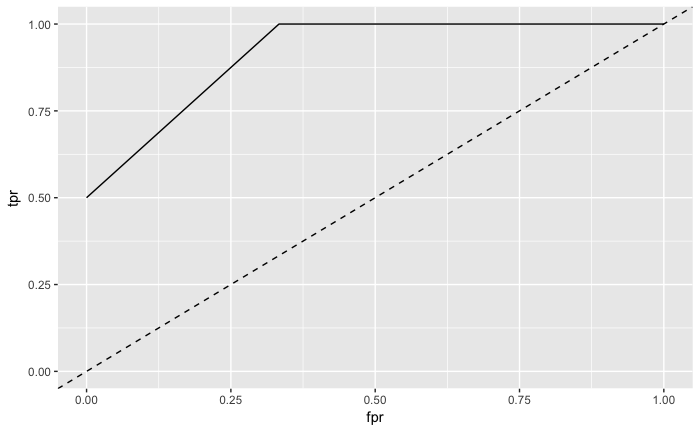

```r
roc = function(pred, dat){
  tpr = sapply(sort(unique(pred), decreasing=T), function(x) sum(pred >= x & dat)/sum(dat == 1))
  fpr = sapply(sort(unique(pred), decreasing=T), function(x) sum(pred >= x & 1-dat)/sum(dat != 1))
  data.frame(tpr=tpr, fpr=fpr)
}
# e.g.
pred = c(.1, .8, .9, .8, .2)
dat = c(0, 0, 1, 1, 0)
res = roc(pred, dat)
qplot(fpr,tpr, data=res, geom="line") +
  xlim(c(0,1)) + ylim(c(0,1)) +
  geom_abline(intercept = 0, slope=1, linetype="dashed")
```

## Q3: Use the roc curve function to calculate a AUC metric

```r
auc = function(tpr, fpr){
    # trapezoid rule!
   idx = 2:length(tpr)
   return (as.double( (fpr[idx] - fpr[idx-1]) %*% (tpr[idx] + tpr[idx-1])) / 2)
}
# e.g.
dat = c(1,1,1,1,0,1,0,1,0,0)
pred = c(1,0.999,0.999,0.973,0.568,0.421,0.382,0.377,0.146,0.11)
res = roc(pred,dat)
auc(c(0,.27,1), c(0,.2,1))
```

```
[1] 0.535
```

# Data Processing Questions

## Read in the titanic csv and analyze it (e.g. plot interesting fields you find with boxplots, scatterplots, etc.)

### Think about whether the it makes sense to include a column based on what it is.

The “Titanic” dataset is a passenger manifest that also includes a “survived” field, indicating whether the individual survived the trip. We’re interested in whether we can predict whether a passenger survived, based solely on the information we knew about them *before* they boarded the ship.

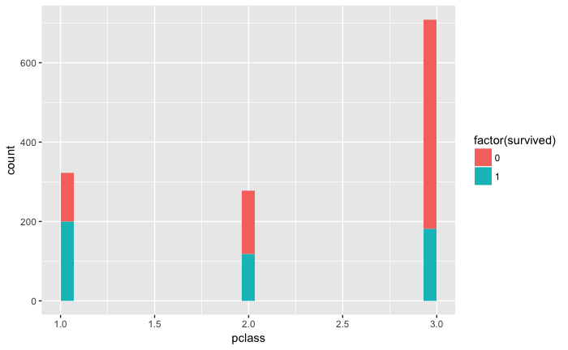

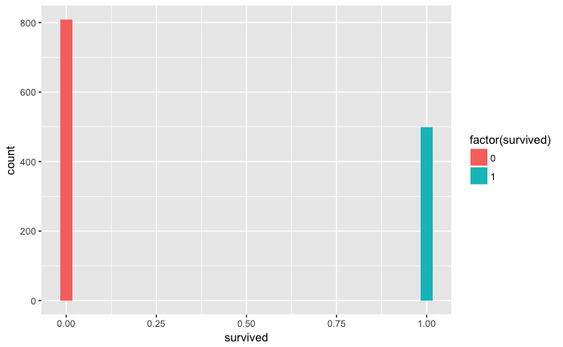

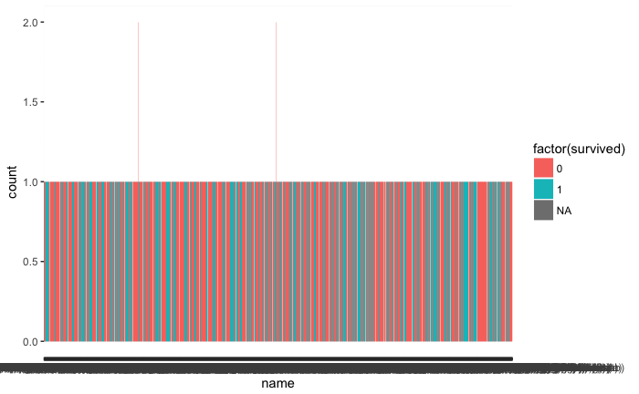

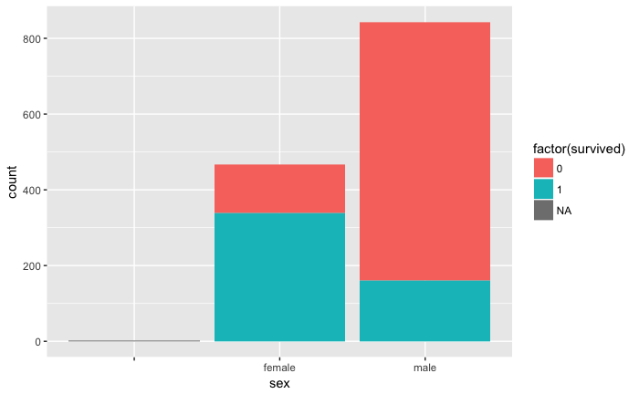

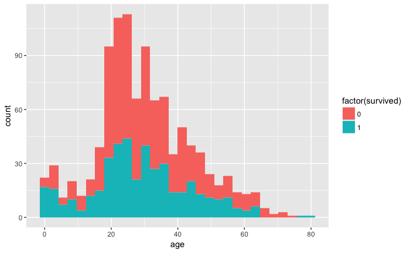

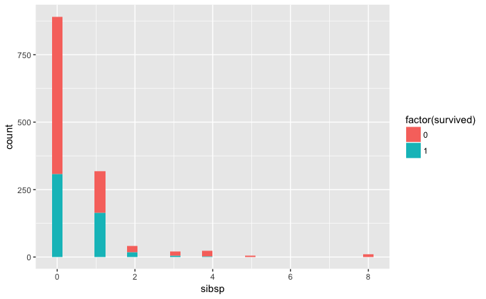

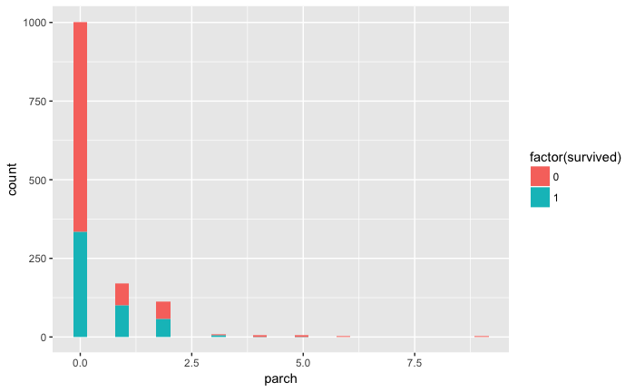

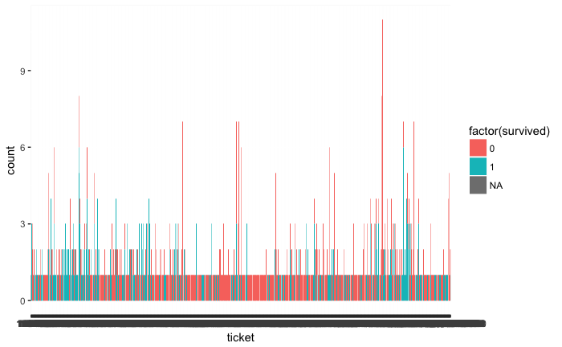

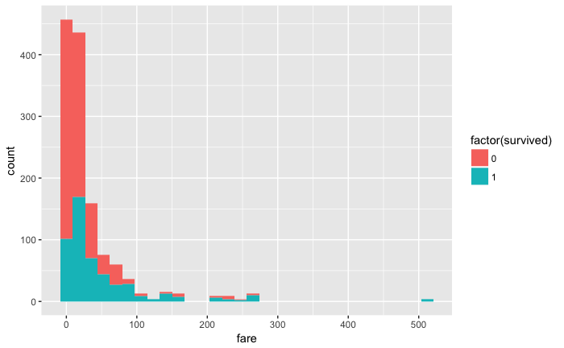

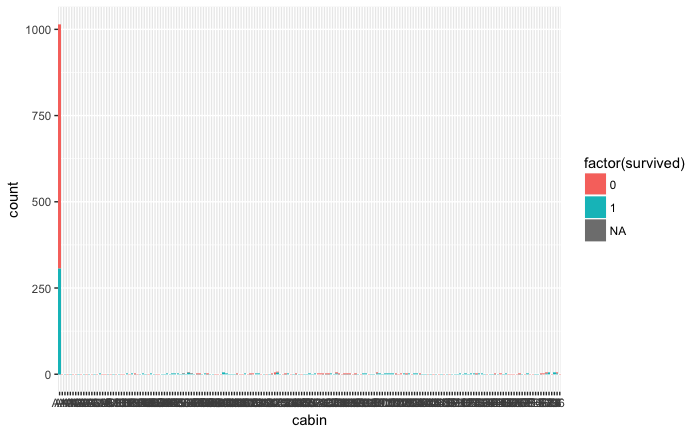

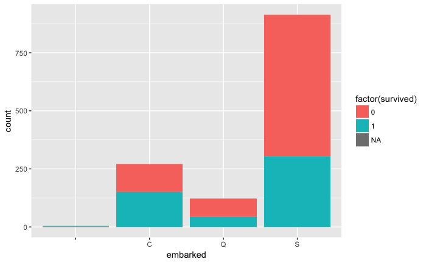

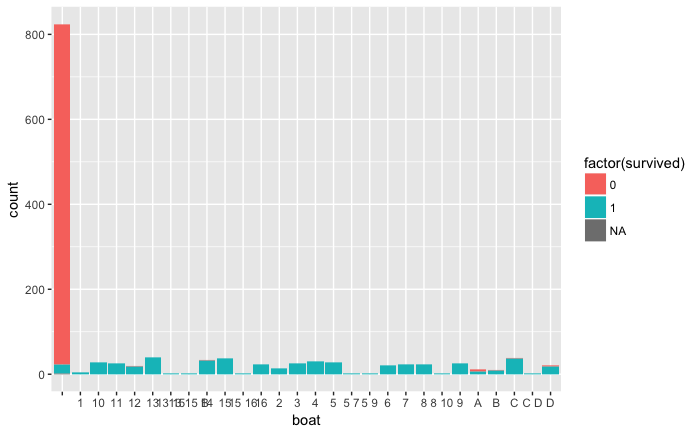

[1 more figures not shown]

```r
titanic = read.csv("https://jdonaldson.github.io/uw-mlearn410/homework/titanic3.csv")
#head(titanic)
names = colnames(titanic)
for (n in 1:length(names)) {
  name = names[n]
  if (!is.numeric(titanic[[name]])){
    stat = "count"
  } else {
    stat = "bin"
  }

  g = ggplot(titanic, aes_string(x=name, fill="factor(survived)")) + geom_histogram(stat = stat)
  print(g)
}
```

```r
graphics.off()
```

Use the plots to answer the following questions:

## Q4: Which fields seem to be important for predicting survival?

pclass, parch, embarked, age, sibsp, sex

## Q5: Which fields are leakage?

boat, body

## Q6: Which fields look like noise?

ticket number, cabin (with one exception!), name

## Q7: Extract the titles from the `name` field

The `name` field contains some useful demographic information. Use `strsplit` and look at the counts of each unique title. These should be values like “Mr.”, “Mrs.”, etc. If there are some that are very low, decide what to do with them - you can create a manual ontology and rename them, create an “Other” class, or drop those rows. Keep in mind - if you drop `null` rows during training, tell us what to do with them while testing/running in production.

```
Ignoring unknown parameters: binwidth, bins, pad
```

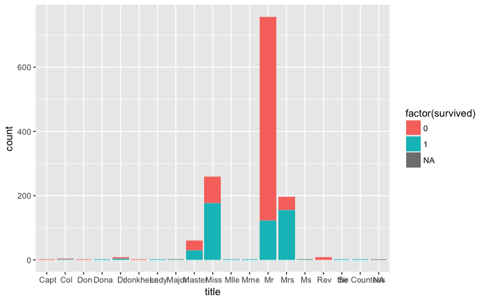

```r
# the title is always the second element
titanic$title = sapply(strsplit(titanic$name, ",|\\."), function(x) x[2])
dev.new()
ggplot(titanic, aes_string(x="title", fill="factor(survived)")) + geom_histogram(stat = "count")
```

## Q8: Deal with NA values

```r
titanic$age = mean(titanic$age, na.rm=T)
top_embarked=names(sort(table(titanic$embarked), decr=T))[1]
titanic$embarked[titanic$embarked == ""]<-top_embarked
any(titanic$embarked == "")
```

```
[1] FALSE
```

```r
any(is.na(titanic$age))
```

```
[1] FALSE
```

## Q9: What assumptions are we implicitly making by using these methods of imputation?

We’re assuming that age has a normal distribution. We’ve also identified that the distribution of embarkation points is heavily skewed towards “S”, making it a good neutral case. We are also making the assumption that the *absence* of port information is not in itself a signal.

## Q10: Convert all the categorical variables into appropriate factors.

Example: What’s the deal with `pclass`? Is it categorical?

```r
titanic = data.frame(lapply(titanic, function(x) if (is.character(x)) factor(x) else if (is.numeric(x)){ x[is.na(x)]<-median(x, na.rm=T); x} else x))
titanic$survived = factor(titanic$survived)
titanic$body = factor(titanic$body)
```

pclass is the status of the ticket type… e.g. first through third class. It’s appropriate to treat as an ordinal variable for the purposes of decision trees. For linear models it is ok in this case because we already spotted a seemingly linear relationship between class number and survivability.

## Q11: Create a sampling function that splits the titanic dataset into 75% train, 25% test dataframe.

```r
datasplit = function(d){
  smp_size <- floor(0.75 * nrow(d))
  train_ind <- sample(seq_len(nrow(d)), size = smp_size)

  train <- d[train_ind, ]
  test <- d[-train_ind, ]
  list(train=train, test=test)
}
split = datasplit(titanic)
split
```

|  | pclass | survived | name | sex | age | sibsp | parch | ticket | fare | cabin | embarked | boat | body | home.dest | title |
| --- | --- | --- | --- | --- | --- | --- | --- | --- | --- | --- | --- | --- | --- | --- | --- |
| 1072 | 3 | 1 | O'Brien, Mrs. Thomas (Johanna "Hannah" Godfrey) | female | 29.88113 | 1 | 0 | 370365 | 15.5000 |  | Q |  | 155 |  | Mrs |
| 1259 | 3 | 1 | Touma, Mrs. Darwis (Hanne Youssef Razi) | female | 29.88113 | 0 | 2 | 2650 | 15.2458 |  | C | C | 155 |  | Mrs |
| 108 | 1 | 1 | Flegenheim, Mrs. Alfred (Antoinette) | female | 29.88113 | 0 | 0 | PC 17598 | 31.6833 |  | S | 7 | 155 | New York, NY | Mrs |
| 1292 | 3 | 0 | Willer, Mr. Aaron ("Abi Weller") | male | 29.88113 | 0 | 0 | 3410 | 8.7125 |  | S |  | 155 |  | Mr |
| 298 | 1 | 1 | Thorne, Mrs. Gertrude Maybelle | female | 29.88113 | 0 | 0 | PC 17585 | 79.2000 |  | C | D | 155 | New York, NY | Mrs |
| 356 | 2 | 1 | Buss, Miss. Kate | female | 29.88113 | 0 | 0 | 27849 | 13.0000 |  | S | 9 | 155 | Sittingbourne, England / San Diego, CA | Miss |
| 1134 | 3 | 0 | Pokrnic, Mr. Mate | male | 29.88113 | 0 | 0 | 315095 | 8.6625 |  | S |  | 155 |  | Mr |
| 1048 | 3 | 1 | Najib, Miss. Adele Kiamie "Jane" | female | 29.88113 | 0 | 0 | 2667 | 7.2250 |  | C | C | 155 |  | Miss |
| 11 | 1 | 0 | Astor, Col. John Jacob | male | 29.88113 | 1 | 0 | PC 17757 | 227.5250 | C62 C64 | C |  | 124 | New York, NY | Col |
| 1196 | 3 | 0 | Shaughnessy, Mr. Patrick | male | 29.88113 | 0 | 0 | 370374 | 7.7500 |  | Q |  | 155 |  | Mr |

[output cut: 972 more lines]

|  | pclass | survived | name | sex | age | sibsp | parch | ticket | fare | cabin | embarked | boat | body | home.dest | title |
| --- | --- | --- | --- | --- | --- | --- | --- | --- | --- | --- | --- | --- | --- | --- | --- |
| 1 | 1 | 1 | Allen, Miss. Elisabeth Walton | female | 29.88113 | 0 | 0 | 24160 | 211.3375 | B5 | S | 2 | 155 | St Louis, MO | Miss |
| 6 | 1 | 1 | Anderson, Mr. Harry | male | 29.88113 | 0 | 0 | 19952 | 26.5500 | E12 | S | 3 | 155 | New York, NY | Mr |
| 14 | 1 | 1 | Barber, Miss. Ellen "Nellie" | female | 29.88113 | 0 | 0 | 19877 | 78.8500 |  | S | 6 | 155 |  | Miss |
| 15 | 1 | 1 | Barkworth, Mr. Algernon Henry Wilson | male | 29.88113 | 0 | 0 | 27042 | 30.0000 | A23 | S | B | 155 | Hessle, Yorks | Mr |
| 16 | 1 | 0 | Baumann, Mr. John D | male | 29.88113 | 0 | 0 | PC 17318 | 25.9250 |  | S |  | 155 | New York, NY | Mr |
| 18 | 1 | 1 | Baxter, Mrs. James (Helene DeLaudeniere Chaput) | female | 29.88113 | 0 | 1 | PC 17558 | 247.5208 | B58 B60 | C | 6 | 155 | Montreal, PQ | Mrs |
| 31 | 1 | 0 | Blackwell, Mr. Stephen Weart | male | 29.88113 | 0 | 0 | 113784 | 35.5000 | T | S |  | 155 | Trenton, NJ | Mr |
| 39 | 1 | 0 | Brady, Mr. John Bertram | male | 29.88113 | 0 | 0 | 113054 | 30.5000 | A21 | S |  | 155 | Pomeroy, WA | Mr |
| 41 | 1 | 0 | Brewe, Dr. Arthur Jackson | male | 29.88113 | 0 | 0 | 112379 | 39.6000 |  | C |  | 155 | Philadelphia, PA | Dr |
| 42 | 1 | 1 | Brown, Mrs. James Joseph (Margaret Tobin) | female | 29.88113 | 0 | 0 | PC 17610 | 27.7208 | B4 | C | 6 | 155 | Denver, CO | Mrs |

[output cut: 318 more lines]

```
NA
```

# Modeling Questions

## Q12: Is accuracy a good metric for evaluating this model? If so, what is the “chance” level for this dataset?

It’s not bad, the classes are fairly evenly distributed (800/500)

## Q13: Use caret/rpart to train a decision tree on the test dataset.

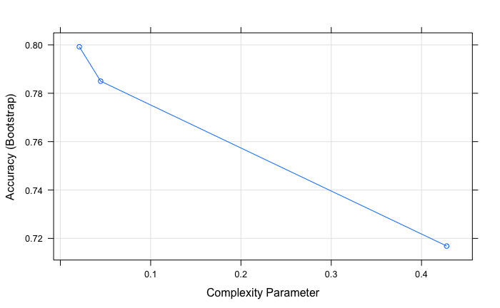

## Q14: Use caret/rf to train a random forest on the test dataset.

```r
 train(survived ~ . , data=traind, method="rf")
```

[output not shown]

## Q15: Use caret/glm to train a logistic model on the test dataset

```r
# e.g., use your train data:
# lmm = train(survived ~ ? , data=split$train, method="glm")
# summary(lmm)
```

## Q16: Gather predictions from your models on the test dataset

```r
# e.g.
# tm_eval  = predict(tm, split$test)
#...
```

## Q17: Use your roc/auc functions to plot and compare your models’ performance

```r
#e.g
# plot(roc(tm_eval, split$test$survived))
# auc(roc(tm_eval, split$test$survived))
```

## Q17: Which model performed the best and why do you think it did better?

# Closing Notes/Follow-up

Consider submitting your responses to Kaggle and see how you did! https://www.kaggle.com/c/titanic